```yaml
---
title: "Household Vulnerability Analysis in Togo"
author: "KAGNIRA Bihèbè"
date: "March 29, 2026"
output:
  html_document:
    toc: true
    toc_depth: 3
    number_sections: true
    theme: cosmo
    highlight: tango
---
```

# Executive Summary

This project analyzes household vulnerability in Togo using survey data (n = 6,749).

This project demonstrates data cleaning, feature engineering, statistical modeling, and policy-oriented interpretation using R.

# 1. Contexte du projet

Ce projet illustre un flux complet d’analyse de données d’enquête ménage au Togo, depuis l’import d’une base SPSS jusqu’à la construction d’un indicateur de vulnérabilité et l’estimation d’un modèle de régression logistique. L’objectif est de montrer ma capacité à nettoyer des données, produire des indicateurs pertinents, les visualiser et interpréter des résultats statistiques dans un cadre reproductible.

# 2. Import et préparation des données

## 2.1 Chargement des données SPSS

```r
setwd("C:/Users/LENOVO/Desktop/KAGNIRA/Projets/projet2")

donnees <- read_sav("./donnees2/donneesbrutes/BASE_SAN.sav")

donnees
```

```
## # A tibble: 6,749 × 113
##    end         logo   q01   q02 q03           ADMIN1Name   ADMIN2Name ADMIN3Name
##    <date>     <dbl> <dbl> <dbl> <chr>         <chr+lbl>    <dbl+lbl>  <dbl+lbl>
##  1 2025-09-09    NA     1 45909 07:42:00.000Z plate… [Pla… 320 [Agou] 3202 [Ago…
##  2 2025-09-10    NA     1 45910 04:17:00.000Z savan… [Sav… 630 [Oti]  6302 [Oti…
##  3 2025-09-10    NA     1 45910 09:55:00.000Z centr… [Cen… 415 [Blit… 4151 [Bli…
##  4 2025-09-10    NA     2 45910 11:38:00.000Z centr… [Cen… 415 [Blit… 4151 [Bli…
##  5 2025-09-10    NA     3 45910 12:48:00.000Z centr… [Cen… 415 [Blit… 4151 [Bli…
##  6 2025-09-10    NA     1 45910 14:06:00.000Z kara [Kara]  520 [Dank… 5203 [Dan…
##  7 2025-09-10    NA     1 45910 12:14:00.000Z savan… [Sav… 610 [Cink… 6102 [Cin…
##  8 2025-09-10    NA     2 45910 15:43:00.000Z kara [Kara]  520 [Dank… 5203 [Dan…
##  9 2025-09-10    NA     1 45910 10:35:00.000Z plate… [Pla… 310 [Moye… 3101 [Moy…
## 10 2025-09-10    NA     1 45910 06:27:00.000Z centr… [Cen… 415 [Blit… 4151 [Bli…
## # ℹ 6,739 more rows
## # ℹ 105 more variables: ADMIN4Name <dbl+lbl>, q1b5 <dbl+lbl>, ADMIN5Name <chr>,
## #   q1b7 <dbl+lbl>, q1b81 <chr>, `@_q1b81_latitude` <dbl>,
## #   `@_q1b81_longitude` <dbl>, `@_q1b81_altitude` <dbl>,
## #   `@_q1b81_precision` <dbl>, q1b81a <dbl>, q1b81b <dbl>, q1a1b <chr+lbl>,
## #   q1a1c <dbl+lbl>, q1a1d <dbl>, q1a2a <chr+lbl>, q1a2b <dbl+lbl>,
## #   confidentialite <dbl>, q1c1 <dbl+lbl>, q1c7 <dbl+lbl>, ConsentRsn <dbl>, …
```

## 2.2 Sélection des variables utiles et nettoyage de base

```r
base <- donnees %>%
  select(
    region  = ADMIN1Name,
    prefect = ADMIN2Name,
    commune = ADMIN3Name,
    canton  = ADMIN4Name,
    milieu  = q1b7,   # Rural / Urbain
    HHSizeCalc,
    HHWaterSRC,
    HHToiletType,
    HHEnerCookSRC,
    HHTenureType
  )

base_clean <- base %>%
  mutate(
    HHSizeCalc = as.numeric(HHSizeCalc),
    milieu     = as.factor(milieu)
  ) %>%
  filter(
    !is.na(region),
    !is.na(milieu)
  )

glimpse(base_clean)
```

```
## Rows: 6,749
## Columns: 10
## $ region        <chr+lbl> "plateaux", "savanes", "centrale", "centrale", "cent…
## $ prefect       <dbl+lbl> 320, 630, 415, 415, 415, 520, 610, 520, 310, 415, 41…
## $ commune       <dbl+lbl> 3202, 6302, 4151, 4151, 4151, 5203, 6102, 5203, 3101…
## $ canton        <dbl+lbl> 320202, 630208, 415114, 415114, 415114, 520302, 6102…
## $ milieu        <fct> 1, 1, 1, 1, 1, 1, 1, 1, 1, 1, 1, 1, 1, 1, 1, 2, 2, 2, 2,…
## $ HHSizeCalc    <dbl> 7, 14, 10, 10, 10, 5, 4, 11, 3, 7, 8, 8, 1, 5, 6, 8, 8, …
## $ HHWaterSRC    <dbl+lbl> 200, 302, 200, 200, 200, 104, 200, 104, 200, 200, 20…
## $ HHToiletType  <dbl+lbl> 20400, 20400, 10403, 10401, 10402, 20300, 20400, 104…
## $ HHEnerCookSRC <dbl+lbl> 102, 200, 102, 102, 102, 102, 102, 102, 102, 102, 10…
## $ HHTenureType  <dbl+lbl> 101, 101, 101, 101, 101, 101, 101, 101, 102, 101, 10…
```

# 3. Profil socio‑démographique

## 3.1 Taille moyenne des ménages par région et milieu

```r
taille_menage <- base_clean %>%
  group_by(region, milieu) %>%
  summarise(
    n_menages = n(),
    taille_moy = mean(HHSizeCalc, na.rm = TRUE),
    .groups = "drop"
  )

taille_menage %>%
  mutate(taille_moy = round(taille_moy, 2)) %>%
  kable(
    caption = "Taille moyenne des ménages par région et milieu",
    align   = "lrrr"
  )
```

Taille moyenne des ménages par région et milieu

| region | milieu | n_menages | taille_moy |
| --- | --- | --- | --- |
| centrale | 1 | 792 | 7.00 |
| centrale | 2 | 193 | 7.15 |
| kara | 1 | 1084 | 6.92 |
| kara | 2 | 245 | 6.05 |
| maritime | 1 | 923 | 5.61 |
| maritime | 2 | 103 | 5.87 |
| plateaux | 1 | 1827 | 6.01 |
| plateaux | 2 | 305 | 5.16 |
| savanes | 1 | 1079 | 7.67 |
| savanes | 2 | 198 | 6.85 |

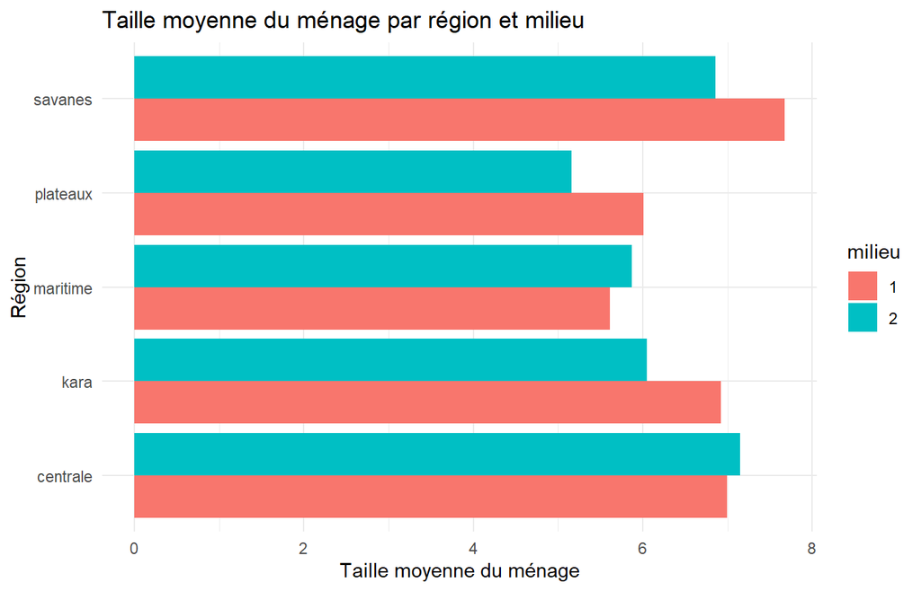

```r
ggplot(taille_menage, aes(x = region, y = taille_moy, fill = milieu)) +
  geom_col(position = "dodge") +
  coord_flip() +
  labs(
    title = "Taille moyenne du ménage par région et milieu",
    x = "Région", y = "Taille moyenne du ménage"
  )
```

## 3.2 Recodage du milieu

```r
base_clean <- base_clean %>%
  mutate(
    milieu = fct_recode(
      milieu,
      "Rural"  = "1",
      "Urbain" = "2"
    )
  )

base_clean %>% count(milieu) %>%
  kable(caption = "Effectifs par milieu de résidence")
```

Effectifs par milieu de résidence

| milieu | n |
| --- | --- |
| Rural | 5705 |
| Urbain | 1044 |

# 4. Conditions de vie – Accès à l’eau

## 4.1 Construction de la variable `eau_cat`

```r
base_clean2 <- base_clean %>%
  mutate(
    eau_cat = case_when(
      HHWaterSRC %in% c(101, 102, 103, 104, 200, 301, 401, 603) ~ "Améliorée",
      HHWaterSRC %in% c(302, 402, 700)                          ~ "Non améliorée",
      HHWaterSRC %in% c(500, 601, 602, 802, 888, 999)           ~ "Autre / indéterminée",
      TRUE                                                      ~ "Inconnue"
    )
  )

base_clean2 %>% count(eau_cat) %>%
  kable(caption = "Répartition des catégories de sources d'eau")
```

Répartition des catégories de sources d’eau

| eau_cat | n |
| --- | --- |
| Améliorée | 5180 |
| Autre / indéterminée | 64 |
| Non améliorée | 1505 |

## 4.2 Répartition des catégories d’eau par région et milieu

```r
eau_region_cat <- base_clean2 %>%
  group_by(region, milieu, eau_cat) %>%
  summarise(n = n(), .groups = "drop") %>%
  group_by(region, milieu) %>%
  mutate(pct = 100 * n / sum(n)) %>%
  ungroup()

eau_region_cat %>%
  mutate(pct = round(pct, 1)) %>%
  kable(
    caption = "Catégories de sources d'eau par région et milieu",
    align   = "lllr"
  )
```

Catégories de sources d’eau par région et milieu

| region | milieu | eau_cat | n | pct |
| --- | --- | --- | --- | --- |
| centrale | Rural | Améliorée | 656 | 82.8 |
| centrale | Rural | Autre / indéterminée | 4 | 0.5 |
| centrale | Rural | Non améliorée | 132 | 16.7 |
| centrale | Urbain | Améliorée | 174 | 90.2 |
| centrale | Urbain | Non améliorée | 19 | 9.8 |
| kara | Rural | Améliorée | 987 | 91.1 |
| kara | Rural | Autre / indéterminée | 3 | 0.3 |
| kara | Rural | Non améliorée | 94 | 8.7 |
| kara | Urbain | Améliorée | 240 | 98.0 |
| kara | Urbain | Non améliorée | 5 | 2.0 |
| maritime | Rural | Améliorée | 611 | 66.2 |
| maritime | Rural | Autre / indéterminée | 7 | 0.8 |
| maritime | Rural | Non améliorée | 305 | 33.0 |
| maritime | Urbain | Améliorée | 97 | 94.2 |
| maritime | Urbain | Autre / indéterminée | 1 | 1.0 |
| maritime | Urbain | Non améliorée | 5 | 4.9 |
| plateaux | Rural | Améliorée | 1218 | 66.7 |
| plateaux | Rural | Autre / indéterminée | 31 | 1.7 |
| plateaux | Rural | Non améliorée | 578 | 31.6 |
| plateaux | Urbain | Améliorée | 232 | 76.1 |
| plateaux | Urbain | Autre / indéterminée | 16 | 5.2 |
| plateaux | Urbain | Non améliorée | 57 | 18.7 |
| savanes | Rural | Améliorée | 789 | 73.1 |
| savanes | Rural | Autre / indéterminée | 1 | 0.1 |
| savanes | Rural | Non améliorée | 289 | 26.8 |
| savanes | Urbain | Améliorée | 176 | 88.9 |
| savanes | Urbain | Autre / indéterminée | 1 | 0.5 |
| savanes | Urbain | Non améliorée | 21 | 10.6 |

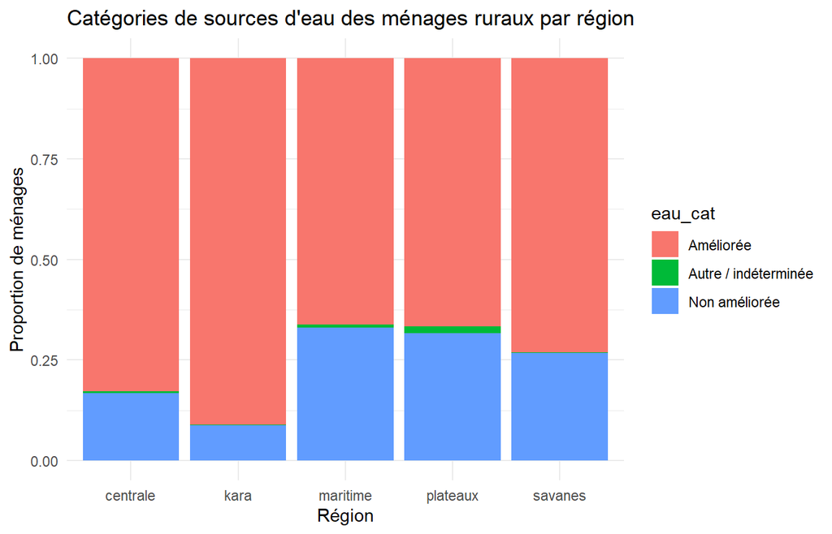

```r
eau_rural_cat <- eau_region_cat %>% filter(milieu == "Rural")

ggplot(eau_rural_cat, aes(x = region, y = pct, fill = eau_cat)) +
  geom_col(position = "fill") +
  labs(
    title = "Catégories de sources d'eau des ménages ruraux par région",
    x = "Région", y = "Proportion de ménages"
  )
```

# 5. Indicateur de vulnérabilité des ménages

This section constructs a household vulnerability indicator based on three key dimensions: access to improved water, sanitation, and cooking energy sources.

## 5.1 Construction de l’indicateur

```r
library(dplyr)

base_vuln <- base_clean2 %>%
  mutate(
    # Indicateurs binaires pour chaque dimension
    eau_non_amelioree = if_else(eau_cat == "Non améliorée", 1L, 0L),
    toilette_non_amelioree = if_else(HHToiletType %in% c(10402, 888, 999), 1L, 0L),
    energie_bois_collecte = if_else(HHEnerCookSRC %in% c(102, 900), 1L, 0L),

    # Score de vulnérabilité
    score_vuln = eau_non_amelioree + toilette_non_amelioree + energie_bois_collecte,

    # Ménage vulnérable si score >= 2
    menage_vulnerable = if_else(score_vuln >= 2, 1L, 0L)
  )
```

```r
# Distribution du score de vulnérabilité
base_vuln %>%
  count(score_vuln)
```

```
## # A tibble: 4 × 2
##   score_vuln     n
##        <int> <int>
## 1          0  1545
## 2          1  3459
## 3          2  1560
## 4          3   185
```

```r
# Proportion de ménages vulnérables
base_vuln %>%
  summarise(
    pct_vuln = round(mean(menage_vulnerable) * 100, 1)
  )
```

```
## # A tibble: 1 × 1
##   pct_vuln
##      <dbl>
## 1     25.9
```

```r
# Comptage des NA pour score et vulnérabilité
base_vuln %>%
  summarise(
    na_score = sum(is.na(score_vuln)),
    na_vuln  = sum(is.na(menage_vulnerable))
  )
```

```
## # A tibble: 1 × 2
##   na_score na_vuln
##      <int>   <int>
## 1        0       0
```

### Missing Value Check

A check for missing values was conducted to evaluate the robustness of the constructed indicators. Results show that all observations have valid values for score_vuln and menage_vulnerable, ensuring reliability of the analysis.

### Key Result

Across the sample,

25.9% of households are classified as vulnerable (vulnerability score ≥ 2), providing a target population for subsequent analyses.

## 5.2 Vulnérabilité par région et milieu

```r
vuln_region <- base_vuln %>%
  group_by(region, milieu) %>%
  summarise(
    n       = n(),
    n_vuln  = sum(menage_vulnerable, na.rm = TRUE),
    pct_vuln = round(100 * n_vuln / n, 1),
    .groups = "drop"
  )

vuln_region %>%
  kable(caption = "Proportion de ménages vulnérables par région et milieu",
        format.args = list(big.mark = " ", digits = 1))
```

Proportion de ménages vulnérables par région et milieu

| region | milieu | n | n_vuln | pct_vuln |
| --- | --- | --- | --- | --- |
| centrale | Rural | 792 | 225 | 28 |
| centrale | Urbain | 193 | 15 | 8 |
| kara | Rural | 1 084 | 175 | 16 |
| kara | Urbain | 245 | 13 | 5 |
| maritime | Rural | 923 | 284 | 31 |
| maritime | Urbain | 103 | 8 | 8 |
| plateaux | Rural | 1 827 | 678 | 37 |
| plateaux | Urbain | 305 | 43 | 14 |
| savanes | Rural | 1 079 | 293 | 27 |
| savanes | Urbain | 198 | 11 | 6 |

[figure not shown]

```r
ggplot(vuln_region, aes(x = region, y = pct_vuln, fill = milieu)) +
  geom_col(position = "dodge") +
  labs(
  title = "Vulnerability Heatmap",
  x = "Region",
  y = "Area type"
)
```

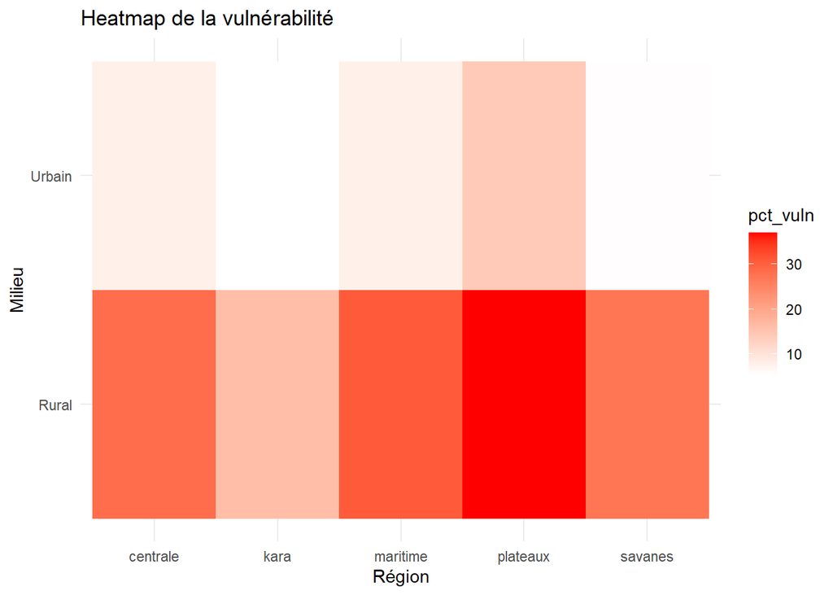

```r
ggplot(vuln_region, aes(x = region, y = milieu, fill = pct_vuln)) +
  geom_tile() +
  scale_fill_gradient(low = "white", high = "red") +
  labs(
    title = "Heatmap de la vulnérabilité",
    x = "Région",
    y = "Milieu"
  )
```

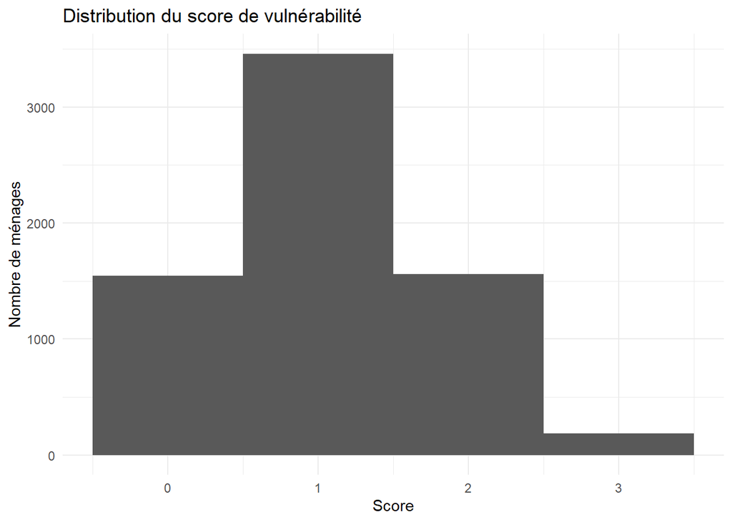

```r
ggplot(base_vuln, aes(x = score_vuln)) +
  geom_histogram(bins = 4) +
  labs(
    title = "Distribution du score de vulnérabilité",
    x = "Score",
    y = "Nombre de ménages"
  )
```

These descriptive analyses highlight key patterns of household vulnerability and identify potential explanatory factors, setting the stage for the logistic regression modeling in Section 6.

# 6. Modélisation : régression logistique

## 6.1 Préparation de la base pour le modèle

```r
base_model <- base_vuln %>%
  filter(
    !is.na(menage_vulnerable),
    !is.na(HHSizeCalc)
  )

base_model$region <- factor(as.character(base_model$region))
base_model$region <- relevel(base_model$region, ref = "maritime")

summary(base_model$region)
```

```
## maritime centrale     kara plateaux  savanes
##     1026      985     1329     2132     1277
```

The Maritime region is used as the reference category, as it includes the capital city and serves as a baseline for comparison.

## 6.2 Ajustement du modèle logit

```r
mod_logit <- glm(
  menage_vulnerable ~ milieu + region + HHSizeCalc,
  data   = base_model,
  family = binomial(link = "logit")
)
summary(mod_logit)
```

```
##
## Call:
## glm(formula = menage_vulnerable ~ milieu + region + HHSizeCalc,
##     family = binomial(link = "logit"), data = base_model)
##
## Coefficients:
##                 Estimate Std. Error z value Pr(>|z|)
## (Intercept)    -0.779619   0.082600  -9.438  < 2e-16 ***
## milieuUrbain   -1.451468   0.114964 -12.625  < 2e-16 ***
## regioncentrale -0.103297   0.103567  -0.997 0.318572
## regionkara     -0.804266   0.106242  -7.570 3.73e-14 ***
## regionplateaux  0.307045   0.084108   3.651 0.000262 ***
## regionsavanes  -0.175066   0.097776  -1.790 0.073376 .
## HHSizeCalc     -0.007073   0.007785  -0.908 0.363632
## ---
## Signif. codes:  0 '***' 0.001 '**' 0.01 '*' 0.05 '.' 0.1 ' ' 1
##
## (Dispersion parameter for binomial family taken to be 1)
##
##     Null deviance: 7714.7  on 6748  degrees of freedom
## Residual deviance: 7314.3  on 6742  degrees of freedom
## AIC: 7328.3
##
## Number of Fisher Scoring iterations: 5
```

The model includes place of residence, region, and household size as key explanatory variables of household vulnerability.

```r
or_logit <- broom::tidy(mod_logit, exponentiate = TRUE, conf.int = TRUE)

or_logit %>%
  filter(term != "(Intercept)") %>%
  mutate(
    OR   = round(estimate, 2),
    IC95 = paste0("[", round(conf.low, 2), " ; ", round(conf.high, 2), "]"),
    p.value = signif(p.value, 3)
  ) %>%
  select(term, OR, IC95, p.value) %>%
  kable(caption = "Modèle logit : odds ratios et intervalles de confiance")
```

Modèle logit : odds ratios et intervalles de confiance

| term | OR | IC95 | p.value |
| --- | --- | --- | --- |
| milieuUrbain | 0.23 | [0.19 ; 0.29] | 0.000000 |
| regioncentrale | 0.90 | [0.74 ; 1.1] | 0.319000 |
| regionkara | 0.45 | [0.36 ; 0.55] | 0.000000 |
| regionplateaux | 1.36 | [1.15 ; 1.6] | 0.000262 |
| regionsavanes | 0.84 | [0.69 ; 1.02] | 0.073400 |
| HHSizeCalc | 0.99 | [0.98 ; 1.01] | 0.364000 |

## 6.3 Évaluation du modèle (AUC - ROC)

```r
library(pROC)

roc_curve <- roc(base_model$menage_vulnerable, fitted(mod_logit))
auc(roc_curve)
```

```
## Area under the curve: 0.6452
```

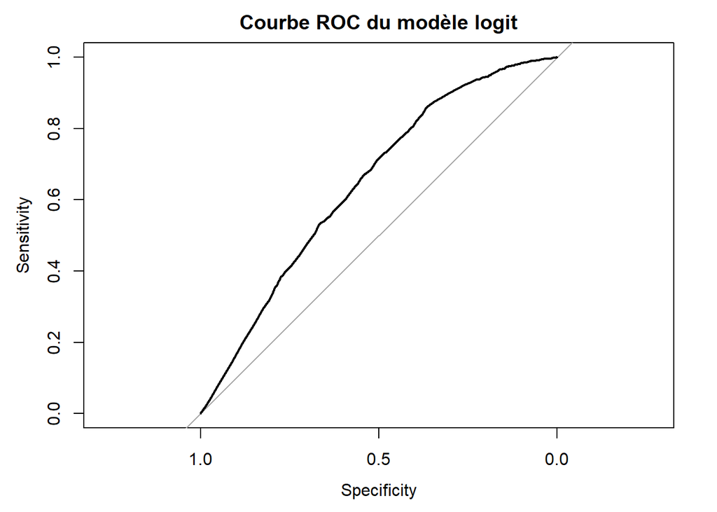

```r
plot(roc_curve, main = "Courbe ROC du modèle logit")
```

The model shows a moderate discriminative ability (AUC ≈ 0.65), indicating that it captures part of the variability in household vulnerability but remains limited in predictive performance.

The moderate AUC suggests that while key factors are captured, additional variables could improve predictive accuracy.

However, the results should be interpreted as associations rather than causal relationships.

## 6.4 Interprétation des résultats du modèle

The results indicate that households living in rural areas have significantly higher odds of being vulnerable compared to urban households.

Overall, these findings confirm the existence of strong structural disparities linked to geography and living conditions.

# 7. Discussion et conclusion

## 7.1 Interprétation des résultats

The logistic regression results presented in Section 6 provide a statistical basis for understanding household vulnerability patterns.

Les résultats montrent une vulnérabilité significativement plus élevée en milieu rural, avec des proportions variant entre 16% et 37% selon les régions. Le milieu urbain est associé à une probabilité nettement plus faible d’être vulnérable, même après prise en compte de la taille du ménage et de la région de résidence, ce que confirment les odds ratios du modèle logit, bien que le pouvoir prédictif du modèle reste modéré (AUC ≈ 0.65).

## 7.2 Limitations

The vulnerability indicator is based on three dimensions (water, sanitation, and energy) and does not capture other important aspects such as income, education, or health. As a result, it should be interpreted as a proxy for basic living conditions rather than a comprehensive measure of poverty.

Future work could extend this approach by incorporating additional socio-economic variables (such as income, education, and health) to build a more robust multidimensional vulnerability index.

In addition, the predictive performance of the model remains moderate, suggesting that key explanatory variables are missing from the analysis.

## 7.3 Conclusion

This analysis provides evidence of strong spatial and rural-urban disparities in household living conditions in Togo, highlighting the need for targeted policy interventions, particularly in rural areas.

It also demonstrates the ability to conduct a complete and rigorous data analysis workflow, from raw survey data to statistical modeling and policy-relevant insights, in a fully reproducible R environment.

# 8. INSIGHTS